# final

## Act 2.1 Implementación de Algoritmos

##### Angel Rubén Vázquez Rivera - A01735407

## 📓 1. Investigacion Documental

Investiga un clasificador y explica sus características principales (Cómo funciona, tipos de datos que maneja, parámetros, tipo de modelo que genera). Omite los ya vistos en clase (knn y árbol) y las redes neuronales. Recuerda agregar las fuentes consultadas

### 🌳 Información Random Forest Classifier

##### ⚙️ ¿Cómo funciona?

Este algoritmo de clasificación genera un conjunto de árboles de decisión independientes que toman diversos muestreos de los datos, asi como atributos o columnas del dataset original, generando de este modo una serie de múltipes escenarios que se pueden evaluar de manera conjunta al resto de árboles dentro del bosque, generando una predicción más exacta en base a todos los escenarios.

A la generación de múltiples árboles de decisión con atributos random y diferentes se le conoce oficialmente como bagging, mientras que una vez que ya se cuentan con múltiples árboles acumulados se realiza el voting, se trata de un proceso de conteo simple, en el que se calcula la cantidad de escenarios o árboles que predicen una clase u otra, llegando asi a dar como predicción general del bosque, a la predicción que más aparezca dentro de todos los árboles.

Modelo de Clasificación.

#### ⚙️ Tipos de datos que acepta

Acepta datos categoricos como objetivo, mientras que numericos en el contenido de cada uno de los atributos del dataset, es decir, es capaz de recibir la misma clase de valores que otros modelos de clasificación como el Knn o árboles de decisión simples.

#### ⚙️ Parámetros

- "n_estimadores": El número de árboles en el ensemble.
- "max_depth": Indicar la profundidad de los árboles dentro dle bosque
- "min_samples_split": Indica el número mínimo de muestras para ser dividido
- "random_state": Genera un valor aleatorio para iniciar con el generador de números pseudoaleatorios y poder reproducir escenarios a pesar de ser randoms.

##### ⚙️ Referencias:

[1]. Scikit-learn. (Año). Random Forests and Other Randomized Tree Ensembles [Página web]. Recuperado de https://scikit-learn.org/stable/modules/ensemble.html#random-forests-and-other-randomized-tree-ensembles

## 📊 2. Implementación de Algoritmos / 3. Experimentación

Para cada algoritmo, generen al menos 5 experimentos variando los parámetros. Obtén la exactitud para cada uno de ellos. Muestra los resultados obtenidos por medio de tablas y/o gráficas

📒 Cada uno de los modelos se encuentra desarrollado en su propio archivo, siendo arbol.ipynb, knn.ipynb y randomForest.ipynb, en la siguiente sección, se invoca la ejecución de cada uno de ellos dentro de este script.

Todos cuentan con un conjunto de datos (70% entrenamiento y 30% evaluación).

##### KNN

```python
%run ./knn.ipynb
```

[output not shown]

[output cut: 2322 more lines]

```
Vecino 4: [6.8, 0.68, 0.21, 2.1, 0.07, 9.0, 23.0, 0.99546, 3.38, 0.6, 10.3, 'Calidad_5'] Distance: 1.4031751172252172
Predicted Class based on neighbors: Calidad_5
Accuracy for this test instance: 100.0


Objective Point: [11.6, 0.42, 0.53, 3.3, 0.105, 33.0, 98.0, 1.001, 3.2, 0.95, 9.2]
Vecino 1: [6.7, 0.28, 0.28, 2.4, 0.012, 36.0, 100.0, 0.99064, 3.26, 0.39, 11.7, 'Calidad_7'] Distance: 6.669187081616469
Vecino 2: [6.7, 0.28, 0.28, 2.4, 0.012, 36.0, 100.0, 0.99064, 3.26, 0.39, 11.7, 'Calidad_7'] Distance: 6.669187081616469
Vecino 3: [9.6, 0.56, 0.23, 3.4, 0.102, 37.0, 92.0, 0.9996, 3.3, 0.65, 10.1, 'Calidad_5'] Distance: 7.551795214384458
Vecino 4: [5.0, 1.04, 0.24, 1.6, 0.05, 32.0, 96.0, 0.9934, 3.74, 0.62, 11.5, 'Calidad_5'] Distance: 7.590262364371867
Predicted Class based on neighbors: Calidad_7
Accuracy for this test instance: 0.0


Overall Accuracy: 86.36363636363636
```

##### Árbol de Decisión

```
Exactitud Con Profundidad de 2: 84.85 %
Exactitud Con Profundidad de 3: 90.15 %
Exactitud Con Profundidad de 4: 89.77 %
Exactitud Con Profundidad de 5: 88.26 %
Exactitud Con Profundidad de 6: 88.64 %
Exactitud Con Profundidad de 7: 86.74 %
```

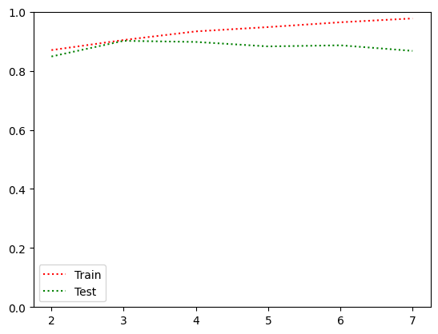

```python
%run ./arbol.ipynb
```

##### 3er Algoritmo

```
Exactitud con 2 arboles:  0.86
Exactitud con 3 arboles:  0.85
Exactitud con 4 arboles:  0.89
Exactitud con 5 arboles:  0.88
Exactitud con 6 arboles:  0.91
```

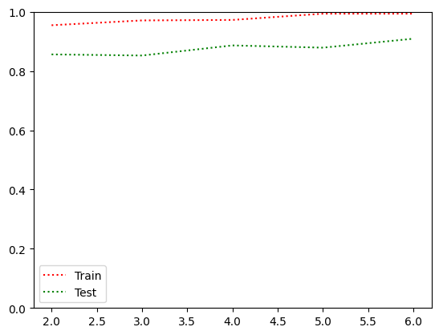

```python
%run ./randomForest.ipynb
```

## 📌 4. Conclusiones

##### ⚙️ ¿Que algoritmo tuvo un mejor desempeño y con que parámetros?

Se le pasaron 4 vecinos mas cercanos como parametro, solo se fueron modificando los puntos de comparación con los datos de testeo, lo que nos llevo a contar con una importante cantidad de exprimentos.

#### ⚙️ ¿Los resultados obtenidos permiten usar estos algoritmos en un consultorio médico? ¿Por qué?

- Knn no me da la seguridad de tomarlo como para algo tan serio, a menos de que los datos estuviesen más balanceados, permitiendo que asi existieran má vecino cercanos con los cuales predecir.
- El random forest, me ofrece más seguridad al analizar múltiples árboles de desición, con múltiples posibilidades, pues al buscar precisiónes basadas en experimientación dentro de cada experimento, se logra una mayor visión de todo el campo.